# Final Project R Notebook

Phil Prosapio, Shayan Khan, Jiyuan Zhou, Bonnie Fan

# Introduction to Data Set

For our final project, our group decided to tackle the Shelter Animal Outcomes Kaggle competition (found here: https://www.kaggle.com/c/shelter-animal-outcomes/data). This data comes from the Austin Animal Center from October 1st, 2013 to March, 2016. To supplement this Kaggle dataset, we went directly to the Austin Animal Center website and downloaded a related dataset that contains intake information about the pets and merged this additional info into our overall dataset (https://data.austintexas.gov/Health-and-Community-Services/Austin-Animal-Center-Intakes/wter-evkm).Fun fact is that one of our group members actually worked at this animal center back in Austin!

This dataset contains information about cats and dogs that were sheltered at the Austin Animal Center. It contains general info about the animals like: type of animal, breed, color, age on outcome, etc.; where the outcome of interest in this competition represent the status of animals as they leave the Animal Center. We needed to merge our intake and outcome datasets and some of the data columns required cleanup or transformation to be of more use to us (e.g. splitting the Sex column into the animals Sex as well as the status of their sexual organs - neutered/intact/etc.), while others were of no value when it comes to trying to apply our models. All animals receive a unique Animal ID during intake.

Our goal is to predict the outcome of animals as they leave the animal center. The outcomes can be one of the following: Adoption, Died, Euthanasia, Return to owner, and Transfer.

The train and test data were randomly split for us already.

It is our belief that producing an accurate and detailed model to help predict outcomes for these shelter animals could help the Austin Animal Center and the animals themselves in a couple ways: - Help the animal center better predict the outcome of a new animal that comes into the shelter. And depending on that predicted outcome, take proactive measures to steer “assist” the animal in receiving a better outcome based on what our model tells us makes for a pet that is more likely to be adopted. - Help the animal center better predict allocation of resources based on what actions might need to be taken for each pet in order to maximize the number of positive outcomes for the shelter animals.

# Exploratory Data Analysis

## Project setup

```r
#Load Libraries
libraries <- c("tidyverse", "ggplot2", "DataExplorer", "gridExtra",
               "reshape", "purrr", "lubridate")

for(lb in libraries){
  # cat(paste(lb))
  if(!(require(lb, character.only = TRUE))){
    install.packages(lb)
  }

  library(lb, character.only = TRUE)
}
```

## Helper Functions for Data Cleanup and EDA

```r
#Helper function to convert values in the AgeuponOutcome/Intake column from time strings (e.g. 1 year, 2 months, etc.) into time in months
timeWarp <- function(age) {
  age_elements <- str_split_fixed(age,"\\s",2)
  norm_age = as.numeric(age_elements[1])
  norm_age
  time_unit = age_elements[2]
  #Based on unit of time, appropriately scale up age variable
  if (grepl(time_unit, "(week)s?")) {
    norm_age = norm_age*7
  } else if (grepl(time_unit, "(months)s?")) {
    norm_age = norm_age*30
  } else if (grepl(time_unit, "(year)s?")) {
    norm_age = norm_age * 365
  }
  return(norm_age / 30)
}
```

## Exploratory Data Analysis of Data

Read in the data from the two different data sources we are using: the animal intake dataset and animal outtake dataset. We then apply the timeWarp function on both data sets to make their age columns into usable values.

```r
#Load in data and start transforming it
animal_out <- read_csv(gzfile("data/train.csv.gz")) %>%
              select(-DateTime, -OutcomeSubtype) %>%
              transform(SexuponOutcome = colsplit(SexuponOutcome, split = "\\s+", names = c('S_Organ_Status_Out', 'Sex_drop')))
animal_in <- read_csv("data/Austin_Animal_Center_Intakes.csv") %>%
             select(-Name, -Breed, -Color, -`Animal Type`) %>%
             transform(`Sex upon Intake` = colsplit(`Sex upon Intake`, split = "\\s+", names = c('S_Organ_Status_In', 'Sex')))
```

## Initial Data Visualization

Check for anything that needs cleaning

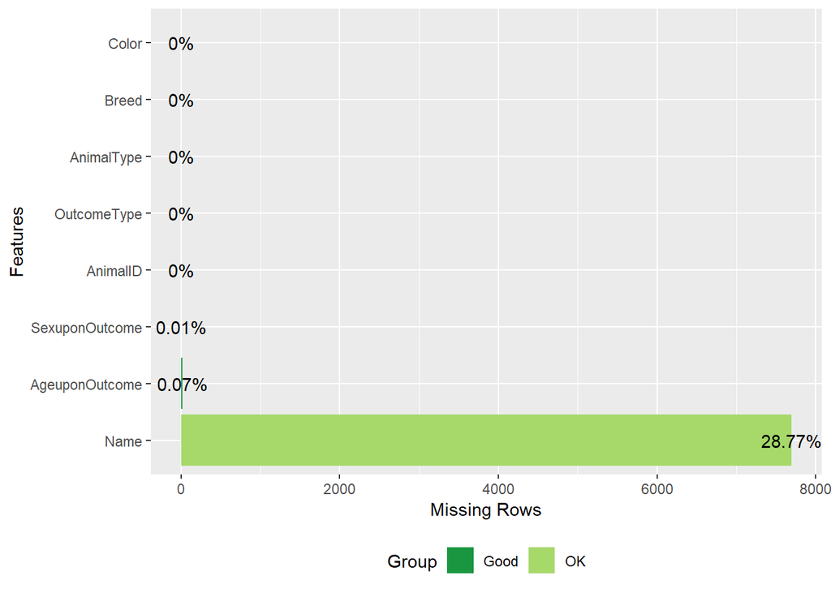

```r
plot_missing(animal_out)
```

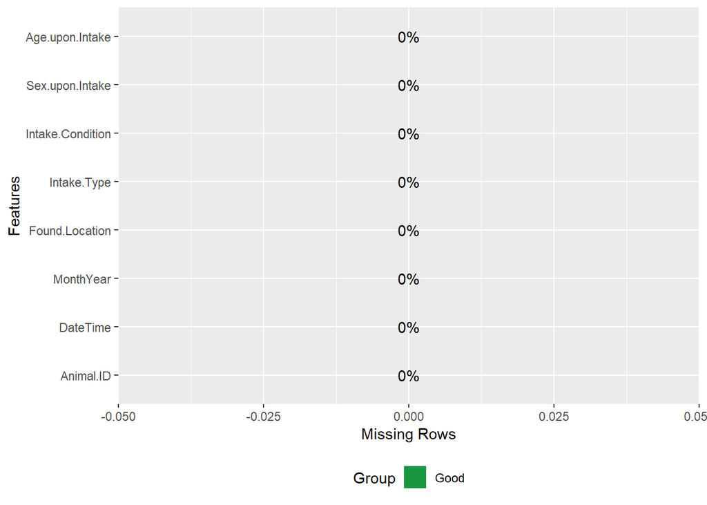

```r
plot_missing(animal_in)
```

```r
glimpse(animal_out)
```

```
## Observations: 26,729
## Variables: 8
## $ AnimalID       <chr> "A671945", "A656520", "A686464", "A683430", "A6...
## $ Name           <chr> "Hambone", "Emily", "Pearce", NA, NA, "Elsa", "...
## $ OutcomeType    <chr> "Return_to_owner", "Euthanasia", "Adoption", "T...
## $ AnimalType     <chr> "Dog", "Cat", "Dog", "Cat", "Dog", "Dog", "Cat"...
## $ SexuponOutcome <data.frame> c("Neutered", "Spayed", "Neutered", "Int...
## $ AgeuponOutcome <chr> "1 year", "1 year", "2 years", "3 weeks", "2 ye...
## $ Breed          <chr> "Shetland Sheepdog Mix", "Domestic Shorthair Mi...
## $ Color          <chr> "Brown/White", "Cream Tabby", "Blue/White", "Bl...
```

```r
glimpse(animal_in)
```

```
## Observations: 92,900
## Variables: 8
## $ Animal.ID        <chr> "A748291", "A750529", "A730601", "A748238", "...
## $ DateTime         <chr> "5/1/2017 14:26", "5/28/2017 13:22", "7/7/201...
## $ MonthYear        <chr> "5/1/2017 14:26", "5/28/2017 13:22", "7/7/201...
## $ Found.Location   <chr> "S Pleasant Valley Rd And E Riverside Dr in A...
## $ Intake.Type      <chr> "Stray", "Stray", "Stray", "Stray", "Owner Su...
## $ Intake.Condition <chr> "Normal", "Normal", "Normal", "Normal", "Nurs...
## $ Sex.upon.Intake  <data.frame> c("Intact", "Intact", "Intact", "Intac...
## $ Age.upon.Intake  <chr> "10 months", "5 months", "7 months", "3 years...
```

## Clean the data

Clean up and split a variety of columns to produce more usable features that can then be used in our models. We’ll first need to clean the data variables

```r
animal_out$AgeuponOutcome <- vapply(animal_out$AgeuponOutcome, FUN = timeWarp, FUN.VALUE = double(1))
animal_in$AgeuponIntake <- vapply(animal_in$Age.upon.Intake, FUN = timeWarp, FUN.VALUE = double(1))
```

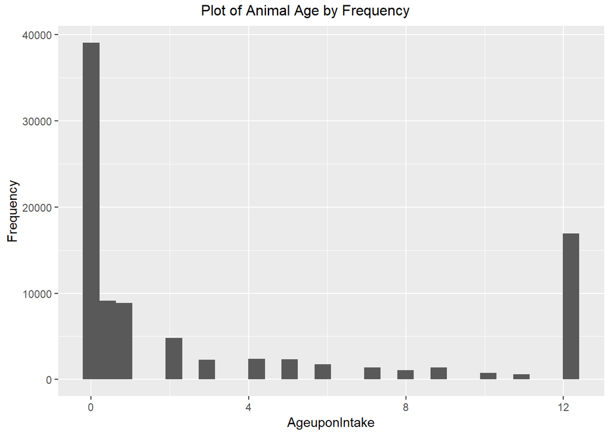

```r
plot_histogram(animal_in, title = "Plot of Animal Age by Frequency")
```

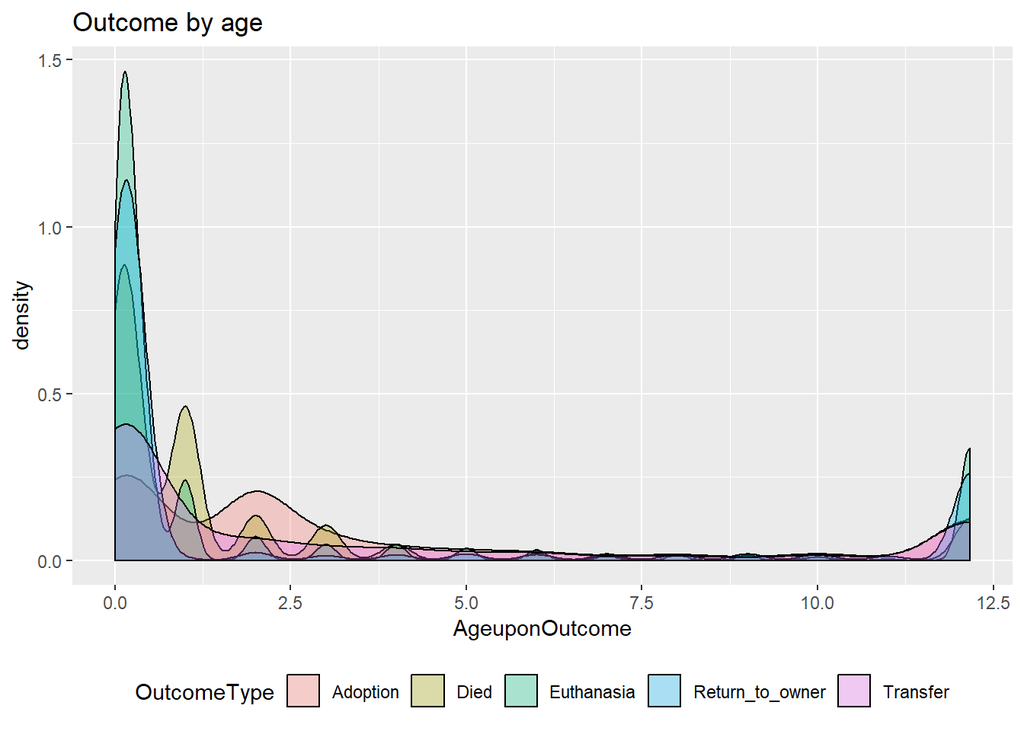

```r
ggplot(animal_out, aes(x=AgeuponOutcome, fill=OutcomeType)) +
  geom_density(alpha=0.3) +
  theme(legend.position="bottom") +
  ggtitle("Outcome by age")
```

Split the SexuponOutcome/Intake columns in order to get access to the pets sex as well as the status of their sexual organs (neutered, intact, etc.)

```r
animal_out$S_Organ_Status_Out <- animal_out$SexuponOutcome$S_Organ_Status_Out
animal_out$Sex_drop <- animal_out$SexuponOutcome$Sex_drop

animal_in$S_Organ_Status_In <- animal_in$Sex.upon.Intake$S_Organ_Status_In
animal_in$Sex <- animal_in$Sex.upon.Intake$Sex

#Convert Name column into factor so we can see if the fact that the pet had a name documented affected it's outcome. 1=Had Name, 0=Name Unknown
animal_out$Name[!is.na(animal_out$Name)] <- 1
animal_out$Name[is.na(animal_out$Name)] <- 0
animal_out$Name <- as.factor(animal_out$Name)

#Final steps of cleaning up my data and then merging it together.
animal_out <- animal_out %>% #cad standing for Cleaned_Animal_Data
       select(-SexuponOutcome, -Sex_drop) %>%
       na.omit()

animal_in <- animal_in %>%
             select(-Sex.upon.Intake, -Age.upon.Intake)

#Inner join to combine data from the intake and outcome data frames and merge each row based on the unique Animal ID.
a_merged <- inner_join(animal_out, animal_in, by = c("AnimalID" = "Animal.ID"), all.x=TRUE) %>%
                   filter(AgeuponIntake <= AgeuponOutcome)
```

```r
glimpse(a_merged)
```

```
## Observations: 28,626
## Variables: 16
## $ AnimalID           <chr> "A671945", "A656520", "A686464", "A683430",...
## $ Name               <fct> 1, 1, 1, 0, 0, 1, 1, 0, 1, 0, 0, 0, 1, 1, 1...
## $ OutcomeType        <chr> "Return_to_owner", "Euthanasia", "Adoption"...
## $ AnimalType         <chr> "Dog", "Cat", "Dog", "Cat", "Dog", "Dog", "...
## $ AgeuponOutcome     <dbl> 12.16666667, 12.16666667, 0.06666667, 0.100...
## $ Breed              <chr> "Shetland Sheepdog Mix", "Domestic Shorthai...
## $ Color              <chr> "Brown/White", "Cream Tabby", "Blue/White",...
## $ S_Organ_Status_Out <fct> Neutered, Spayed, Neutered, Intact, Neutere...
## $ DateTime           <chr> "2/2/2014 9:31", "10/13/2013 11:49", "8/22/...
## $ MonthYear          <chr> "2/2/2014 9:31", "10/13/2013 11:49", "8/22/...
## $ Found.Location     <chr> "1156 Cesar Chavez in Austin (TX)", "Austin...
## $ Intake.Type        <chr> "Stray", "Owner Surrender", "Stray", "Stray...
## $ Intake.Condition   <chr> "Normal", "Normal", "Normal", "Sick", "Norm...
## $ AgeuponIntake      <dbl> 12.16666667, 12.16666667, 0.06666667, 0.100...
## $ S_Organ_Status_In  <fct> Neutered, Spayed, Intact, Intact, Neutered,...
## $ Sex                <fct> Male, Female, Male, Male, Male, Female, Mal...
```

```r
length(unique(a_merged$Breed))
```

```
## [1] 1367
```

## Feature Engineering

First we need to clean the dataset to move “mix” into its own feature and keep only the first breed mentioned for the breed mixes

```r
a_merged <- a_merged %>%
  mutate(mix = ifelse(grepl("mix", Breed, ignore.case = T), 1, 0),
         breed_new = gsub(" Mix", "", Breed),
         breed_new = strsplit(x = breed_new, split = "/"),
         breed_new = map_chr(breed_new, function(x){unlist(x[1])}))
```

Because there are so many separate breeds and colors, it would be difficult to include them in our model. For this reason, we’ll categorize them for analysis.

It does look like there are a number of popular breeds that take up more than 75% of the dataset:

```r
popular <- a_merged %>%
  count(breed_new, sort = TRUE) %>%
  mutate(freq = round(100 * n / sum(n),2)) %>%
  mutate(cumfreq = cumsum(freq)) %>%
  mutate(is_pop = ifelse(cumfreq < 75, 1, 0))

popular %>%
  head(20)
```

| breed_new | n | freq | cumfreq | is_pop |
| --- | --- | --- | --- | --- |
| Domestic Shorthair | 8968 | 31.33 | 31.33 | 1 |
| Pit Bull | 2470 | 8.63 | 39.96 | 1 |
| Chihuahua Shorthair | 2295 | 8.02 | 47.98 | 1 |
| Labrador Retriever | 2121 | 7.41 | 55.39 | 1 |
| German Shepherd | 954 | 3.33 | 58.72 | 1 |
| Domestic Medium Hair | 893 | 3.12 | 61.84 | 1 |
| Australian Cattle Dog | 565 | 1.97 | 63.81 | 1 |
| Domestic Longhair | 556 | 1.94 | 65.75 | 1 |
| Dachshund | 542 | 1.89 | 67.64 | 1 |
| Siamese | 441 | 1.54 | 69.18 | 1 |

[output cut: 10 more lines]

For dogs, the most common breeds are Pit Bulls, Chihuahuas, and Labs.

```r
dog_popular <- a_merged %>%
  filter(AnimalType == 'Dog') %>%
  count(breed_new, sort = TRUE) %>%
  mutate(freq = round(100 * n / sum(n),2)) %>%
  head(16)

print(dog_popular)
```

```
## # A tibble: 16 x 3
##    breed_new                 n  freq
##    <chr>                 <int> <dbl>
##  1 Pit Bull               2470 14.2
##  2 Chihuahua Shorthair    2295 13.2
##  3 Labrador Retriever     2121 12.2
##  4 German Shepherd         954  5.47
##  5 Australian Cattle Dog   565  3.24
##  6 Dachshund               542  3.11
##  7 Boxer                   395  2.26
##  8 Border Collie           381  2.18
##  9 Miniature Poodle        340  1.95
## 10 Beagle                  263  1.51
## 11 Australian Shepherd     252  1.44
## 12 Catahoula               249  1.43
## 13 Rat Terrier             246  1.41
## 14 Jack Russell Terrier    245  1.4
## 15 Yorkshire Terrier       236  1.35
## 16 Miniature Schnauzer     234  1.34
```

80% of Cat breeds appear to be Domestic Shorthair.

```r
cat_popular <- a_merged %>%
  filter(AnimalType == 'Cat') %>%
  count(breed_new, sort = TRUE) %>%
  mutate(freq = round(100 * n / sum(n),2)) %>%
  head(16)

print(cat_popular)
```

```
## # A tibble: 16 x 3
##    breed_new                n  freq
##    <chr>                <int> <dbl>
##  1 Domestic Shorthair    8968 80.3
##  2 Domestic Medium Hair   893  7.99
##  3 Domestic Longhair      556  4.98
##  4 Siamese                441  3.95
##  5 Snowshoe                76  0.68
##  6 Maine Coon              46  0.41
##  7 Manx                    45  0.4
##  8 Russian Blue            37  0.33
##  9 Himalayan               19  0.17
## 10 Persian                 13  0.12
## 11 Ragdoll                 12  0.11
## 12 American Shorthair       9  0.08
## 13 Angora                   7  0.06
## 14 Japanese Bobtail         6  0.05
## 15 Balinese                 5  0.04
## 16 Bengal                   5  0.04
```

```r
popular %>%
  filter(is_pop == 1) %>%
  select(breed_new) -> common

a_merged <- a_merged %>%
  mutate(breed_common = ifelse(breed_new %in% common$breed_new, 1, 0))
```

For the ~200 most common breeds, we classified them based on categories outlined by the American Kennel Club. These categories include “Working,” “Sporting,” “Non-sporting” and “Toy” for dogs, and “Domestic Shorthair” and “Other Cat” for cats. We then mapped each of the breeds to their corresponding category, and saved the mapping in a data frame. Finally, we joined the breed grouping data frame with our existing dataset to add the breed category information.

```r
breed_groups <- read.csv("breedGroups.csv")
names(breed_groups) <- c("breed_new", "breed_group")
#color_groups <- read.csv("colorGroups.csv", row.names = NULL)

a_merged <- inner_join(a_merged, breed_groups, by = "breed_new")
#a_merged <- left_join(a_merged, color_groups, by = c("Color" = "colors"))
```

## Save off data frame for use at later points

```r
write.csv(a_merged, file="Data/Cleaned_Data_Frame.csv")
```

## Graphical Analysis of Dataset for EDA

First we leverage the DataExplorer plot_bar function to get an initial feel for how our variables are distributed.

```
## 7 columns ignored with more than 50 categories.
## AnimalID: 25938 categories
## Breed: 1366 categories
## Color: 363 categories
## DateTime: 21666 categories
## MonthYear: 21666 categories
## Found.Location: 14832 categories
## breed_new: 218 categories
```

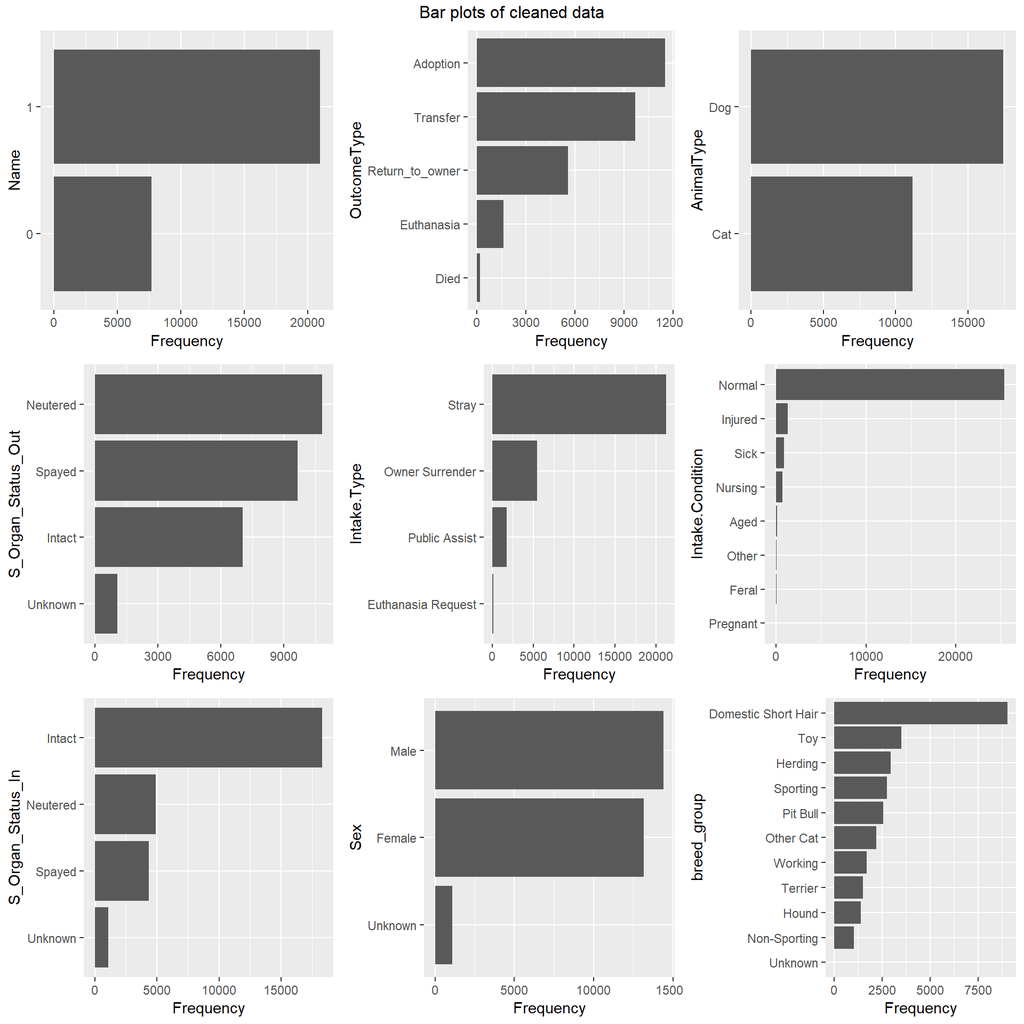

```r
a_merged %>%
    plot_bar(title = "Bar plots of cleaned data")
```

```r
glimpse(a_merged)
```

```
## Observations: 28,623
## Variables: 20
## $ AnimalID           <chr> "A671945", "A656520", "A686464", "A683430",...
## $ Name               <fct> 1, 1, 1, 0, 0, 1, 1, 0, 1, 0, 0, 0, 1, 1, 1...
## $ OutcomeType        <chr> "Return_to_owner", "Euthanasia", "Adoption"...
## $ AnimalType         <chr> "Dog", "Cat", "Dog", "Cat", "Dog", "Dog", "...
## $ AgeuponOutcome     <dbl> 12.16666667, 12.16666667, 0.06666667, 0.100...
## $ Breed              <chr> "Shetland Sheepdog Mix", "Domestic Shorthai...
## $ Color              <chr> "Brown/White", "Cream Tabby", "Blue/White",...
## $ S_Organ_Status_Out <fct> Neutered, Spayed, Neutered, Intact, Neutere...
## $ DateTime           <chr> "2/2/2014 9:31", "10/13/2013 11:49", "8/22/...
## $ MonthYear          <chr> "2/2/2014 9:31", "10/13/2013 11:49", "8/22/...
## $ Found.Location     <chr> "1156 Cesar Chavez in Austin (TX)", "Austin...
## $ Intake.Type        <chr> "Stray", "Owner Surrender", "Stray", "Stray...
## $ Intake.Condition   <chr> "Normal", "Normal", "Normal", "Sick", "Norm...
## $ AgeuponIntake      <dbl> 12.16666667, 12.16666667, 0.06666667, 0.100...
## $ S_Organ_Status_In  <fct> Neutered, Spayed, Intact, Intact, Neutered,...
## $ Sex                <fct> Male, Female, Male, Male, Male, Female, Mal...
## $ mix                <dbl> 1, 1, 1, 1, 0, 0, 1, 1, 1, 0, 1, 1, 1, 1, 1...
## $ breed_new          <chr> "Shetland Sheepdog", "Domestic Shorthair", ...
## $ breed_common       <dbl> 0, 1, 1, 1, 0, 0, 1, 1, 0, 0, 1, 0, 1, 0, 0...
## $ breed_group        <fct> Herding, Domestic Short Hair, Pit Bull, Dom...
```

Various ggplots we created to help gain detailed information about a couple of the important variables in our dataset.

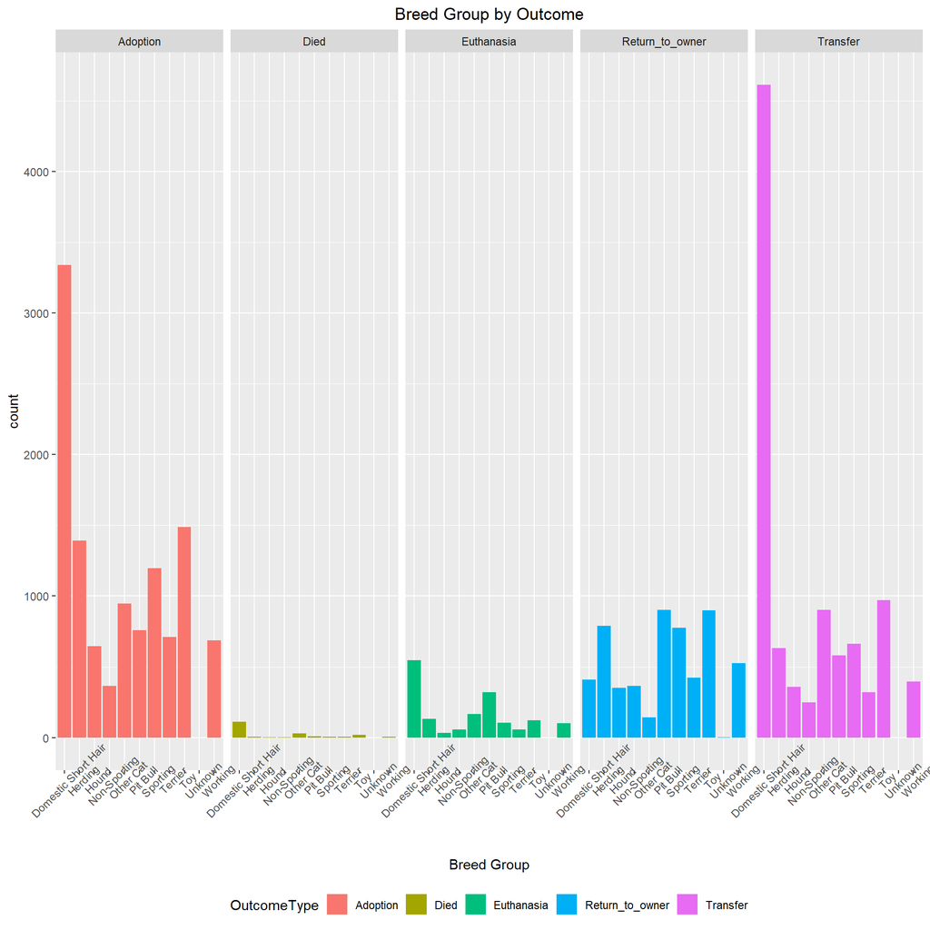

```r
g <- ggplot(data=a_merged, aes(x=breed_group, fill= OutcomeType ))
g + geom_bar(stat="count", position=position_dodge()) +
    xlab("Breed Group") +
    ggtitle("Breed Group by Outcome") +
    facet_grid(~ OutcomeType) +
    theme(axis.text.x  = element_text(angle=45),
          legend.position = "bottom",
          plot.title = element_text(hjust = 0.5))
```

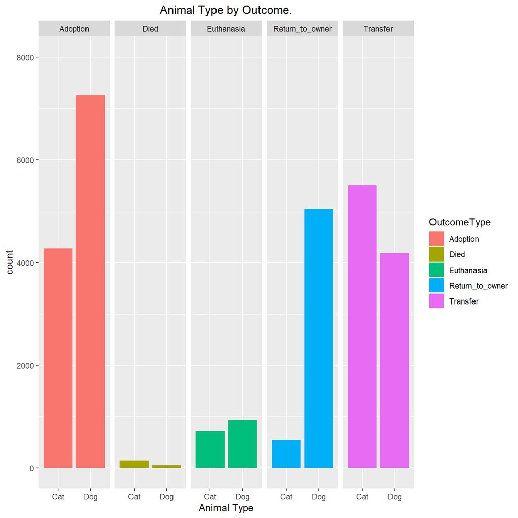

```r
g <- ggplot(data=a_merged, aes(x=AnimalType, fill= OutcomeType ))
g + geom_bar(stat="count", position=position_dodge()) +
    xlab("Animal Type") +
    ylim(0, 8000) +
    ggtitle("Animal Type by Outcome.") +
    facet_grid(~ OutcomeType) +
    theme(plot.title = element_text(hjust = 0.5))
```

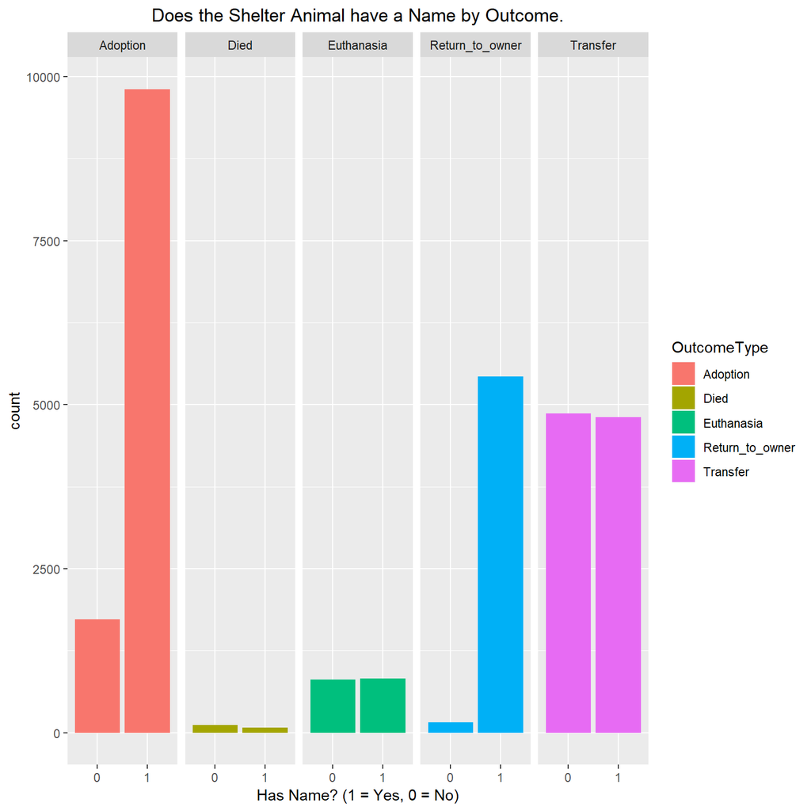

```r
g <- ggplot(data=a_merged, aes(x=Name, fill= OutcomeType ))
g + geom_bar(stat="count", position=position_dodge()) +
    xlab("Has Name? (1 = Yes, 0 = No)") +
    ggtitle("Does the Shelter Animal have a Name by Outcome.") +
    facet_grid(~ OutcomeType) +
    theme(plot.title = element_text(hjust = 0.5))
```

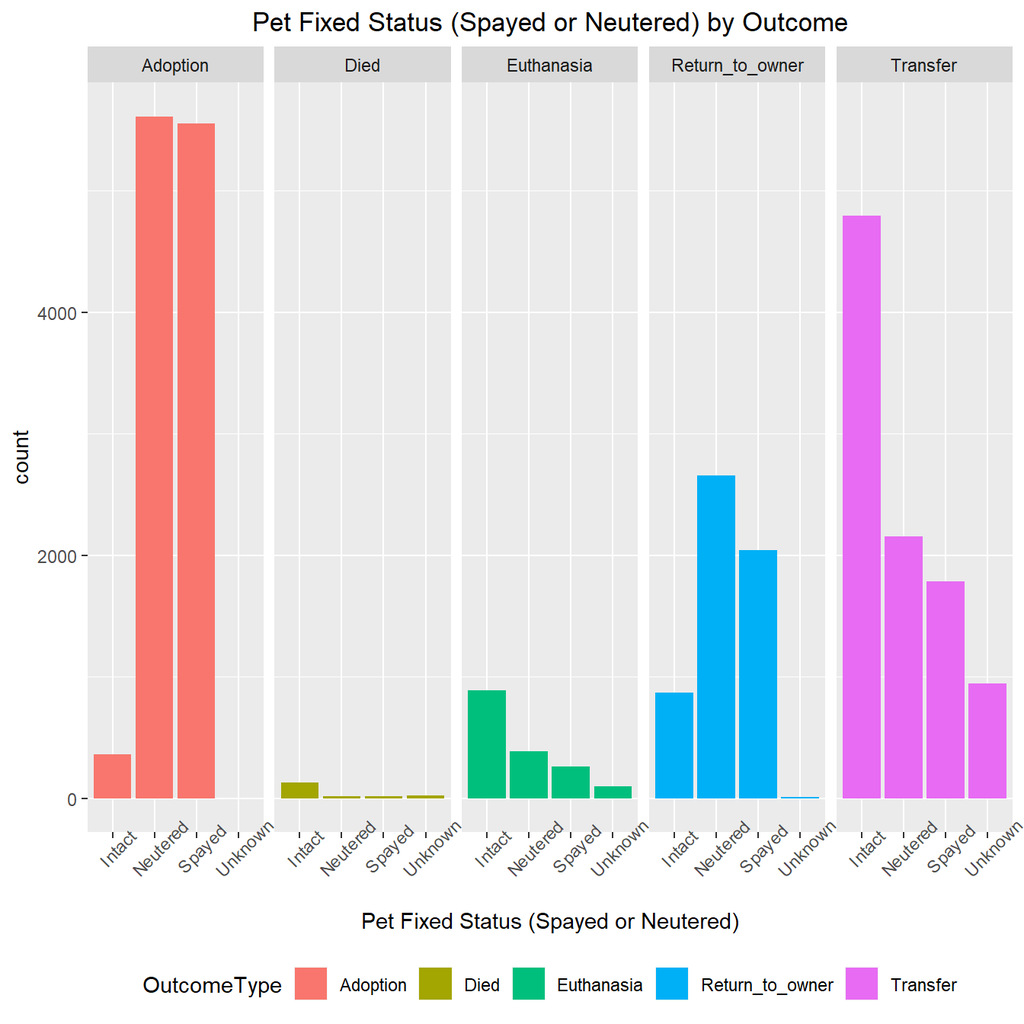

```r
g <- ggplot(data=a_merged, aes(x=S_Organ_Status_Out, fill= OutcomeType ))
g + geom_bar(stat="count", position=position_dodge()) +
    theme(axis.text.x  = element_text(angle=45),
          legend.position = "bottom",
          plot.title = element_text(hjust = 0.5)) +
    xlab("Pet Fixed Status (Spayed or Neutered)") +
    ggtitle("Pet Fixed Status (Spayed or Neutered) by Outcome") +
    facet_grid(~ OutcomeType)
```

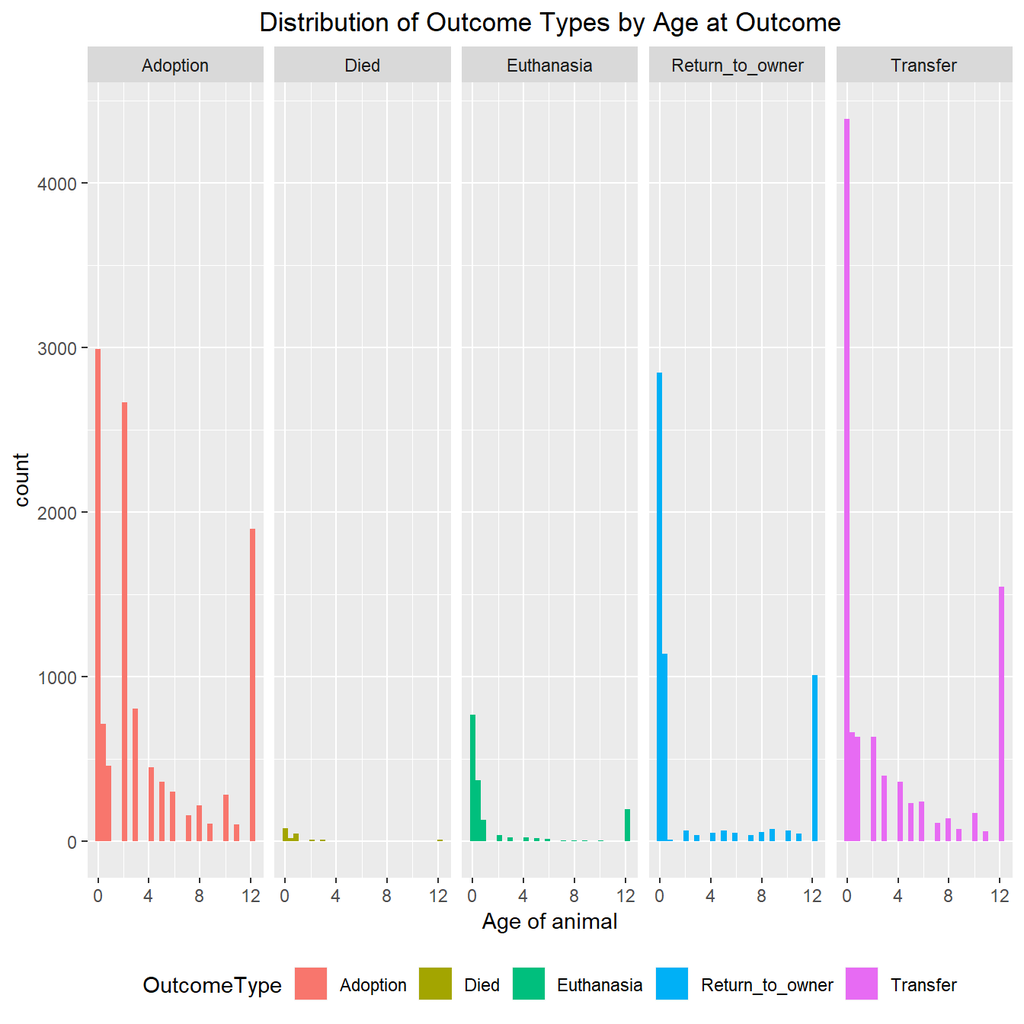

```r
g <- ggplot(data=a_merged, aes(x=AgeuponOutcome, fill= OutcomeType ))
g + geom_bar(stat="bin", position=position_dodge()) +
    xlab("Age of animal") +
    ggtitle("Distribution of Outcome Types by Age at Outcome") +
    theme(legend.position = "bottom") +
    facet_grid(~ OutcomeType) +
    theme(plot.title = element_text(hjust = 0.5))
```

# Data Cleaning and EDA Conclusions for our Dataset

Following our steps to clean, transform, and graph our Animal Shelter dataset, we have found a couple interesting factors in play within our dataset.

One of the first, and most positive, insights we get from our last graph (Distribution of Outcome Types by Age at Outcome) is that the majority of shelter animals at the Austin Animal Center do not end up dying or getting euthanized. The majority end up being adopted, transferred, or returned to their owner. Which is a comforting thing to know for animal lovers.

The most important decision that came out of our data cleaning and transformation process has to do with our decision not to include any outcome variables that were provided in the original dataset (other than animal’s fixed status and age upon outcome**), due to the fact that we felt this would be unrealistic to include in our modeling portion of the project. The reasoning being that since the animal shelter would look to use our models to help predict animal outcomes and provide resources to increase an animals chance for a positive outcome, they would not know an animal’s outcome information in advance. Thus moving forward into our modeling portion of the project, we foucs our attention on data that the animal shelter would be able to assess from an animal upon intake to the shelter.

**The reasons we decided to keep the animal’s fixed status and age upon outcome has to do with the following:

Fixed Status: A shelter can leverage it’s resources to perform procedures on their shelter animals and knowing what fixed statuses lead to better outcomes would help them better decide which animals might benefiit from surgical intervention.

Age Upon Outcome: In a similar vein, shelters can work to advertise certain animals that they realize are approaching certain ages that our models predict lead to worse outcomes. While ideally we would not need to know this info for training our model, we decided to include it since we felt this info was still actionable for the shelter to be able to use.